# Projekt zaliczeniowy

Tomasz Michalski, Aleksander Mikucki

17 06 2020

```r
library(tree)
library(randomForest)
library(gbm)
```

## Wstęp

W projekcie korzystamy ze zbioru Bike Sharing Demand:  
https://www.kaggle.com/c/bike-sharing-demand/  
Zawiera on godzinowe dane dot. wynajmu rowerów obejmujące dwa lata.  
Projekt ma na celu porównanie różnych metod statystycznych i ich jakości w przewidywaniu liczby wynajętych rowerów.

### Ładowanie danych

Podzieliliśmy kolumnę `datetime` poprzez wyeksportowanie do osobnych kolumn miesiąca, dnia i godziny.  
Usunęliśmy także kolumny `casual` i `registered`, gdyż chcemy skupić się na kolumnie `count`, która jest ich sumą.

```r
bike <- read.csv("data.csv", header = TRUE)
bike <- bike[bike$datetime >= "2012-01-01 00:00:00", ]
bike <- bike[, -c(10, 11)]

bike$datetime <-as.POSIXct(bike$datetime, format="%Y-%m-%d %H:%M:%S")
bike$month <- strftime(bike$datetime, '%m')
bike$month <- as.integer(bike$month)
bike$day <-  strftime(bike$datetime, '%d')
bike$day <- as.integer(bike$day)
bike$hour <- substring(bike$datetime, 12,13)
bike$hour <- as.integer(bike$hour)

bike <- bike[,-1]

set.seed(1)
n <- nrow(bike)
train <- sample(1:n, n / 2)
test <- -train
```

### Prezentacja danych

```r
cat("Wierszy w zbiorze: ", nrow(bike), "\n")
```

```
## Wierszy w zbiorze:  5464
```

```r
head(bike)
```

```
##      season holiday workingday weather  temp  atemp humidity windspeed count
## 5423      1       0          0       1 14.76 18.940       66    0.0000    48
## 5424      1       0          0       1 14.76 17.425       66    8.9981    93
## 5425      1       0          0       1 13.12 17.425       76    0.0000    75
## 5426      1       0          0       1 12.30 16.665       81    0.0000    52
## 5427      1       0          0       1 11.48 15.150       81    6.0032     8
## 5428      1       0          0       1 11.48 14.395       81    7.0015     5
##      month day hour
## 5423     1   1    0
## 5424     1   1    1
## 5425     1   1    2
## 5426     1   1    3
## 5427     1   1    4
## 5428     1   1    5
```

## Regresja liniowa

### Regresja dla każdego predyktora osobno

Dopasowujemy model prostej regresji dla każdego predyktora osobno.

```r
simple_coef <- c()
for (predictor in names(bike)) {
  if (predictor != "count") {
    lmFitSimple <- lm(count ~ bike[, predictor], data = bike, subset = train)
    simple_coef <- append(simple_coef, lmFitSimple$coefficients[2])
    cat("########", predictor)
    print(summary(lmFitSimple))
  }
}
```

```
## ######## season
## Call:
## lm(formula = count ~ bike[, predictor], data = bike, subset = train)
##
## Residuals:
##     Min      1Q  Median      3Q     Max
## -285.41 -169.54  -38.97  109.69  723.06
##
## Coefficients:
##                   Estimate Std. Error t value Pr(>|t|)
## (Intercept)        156.528      9.553  16.385   <2e-16 ***
## bike[, predictor]   32.471      3.507   9.258   <2e-16 ***
## ---
## Signif. codes:  0 '***' 0.001 '**' 0.01 '*' 0.05 '.' 0.1 ' ' 1
##
## Residual standard error: 205.4 on 2730 degrees of freedom
## Multiple R-squared:  0.03044,    Adjusted R-squared:  0.03009
## F-statistic: 85.71 on 1 and 2730 DF,  p-value: < 2.2e-16
##
## ######## holiday
## Call:
## lm(formula = count ~ bike[, predictor], data = bike, subset = train)
##
## Residuals:
##     Min      1Q  Median      3Q     Max
## -236.42 -181.42  -38.42  115.58  739.58
##
## Coefficients:
##                   Estimate Std. Error t value Pr(>|t|)
## (Intercept)        237.420      4.049  58.639   <2e-16 ***
## bike[, predictor]   -9.471     23.810  -0.398    0.691
## ---
## Signif. codes:  0 '***' 0.001 '**' 0.01 '*' 0.05 '.' 0.1 ' ' 1
##
## Residual standard error: 208.5 on 2730 degrees of freedom
## Multiple R-squared:  5.795e-05,  Adjusted R-squared:  -0.0003083
## F-statistic: 0.1582 on 1 and 2730 DF,  p-value: 0.6908
##
## ######## workingday
## Call:
```

[output cut: 153 more lines]

```
##
## Residuals:
##     Min      1Q  Median      3Q     Max
## -369.78 -123.67  -46.21   87.39  659.15
##
## Coefficients:
##                   Estimate Std. Error t value Pr(>|t|)
## (Intercept)        87.2056     6.9391   12.57   <2e-16 ***
## bike[, predictor]  13.1556     0.5209   25.26   <2e-16 ***
## ---
## Signif. codes:  0 '***' 0.001 '**' 0.01 '*' 0.05 '.' 0.1 ' ' 1
##
## Residual standard error: 187.8 on 2730 degrees of freedom
## Multiple R-squared:  0.1894, Adjusted R-squared:  0.1891
## F-statistic: 637.9 on 1 and 2730 DF,  p-value: < 2.2e-16
```

Otrzymaliśmy wysoką istotność statystyczną dla predyktorów `season`, `weather`, `temp`, `atemp`, `humidity`, `windspeed`, `month`, oraz `hour`.

### Regresja wielokrotna

Wykonujemy regresję zmiennej `count` względem wszystkich pozostałych.

```r
lmFit <- lm(count ~ ., data = bike, subset = train)
summary(lmFit)
```

```
##
## Call:
## lm(formula = count ~ ., data = bike, subset = train)
##
## Residuals:
##     Min      1Q  Median      3Q     Max
## -324.41 -114.91  -41.76   77.83  661.78
##
## Coefficients:
##             Estimate Std. Error t value Pr(>|t|)
## (Intercept)  79.6658    22.3232   3.569 0.000365 ***
## season      -24.6555    12.6402  -1.951 0.051211 .
## holiday       3.6106    20.2650   0.178 0.858603
## workingday    9.1294     7.3307   1.245 0.213106
## weather       0.2847     5.7855   0.049 0.960750
## temp          2.4973     1.9666   1.270 0.204254
## atemp         4.1873     1.8030   2.322 0.020287 *
## humidity     -2.8251     0.2239 -12.615  < 2e-16 ***
## windspeed     0.7474     0.4408   1.696 0.090057 .
## month        17.5273     4.1266   4.247 2.24e-05 ***
## day           0.1535     0.5968   0.257 0.797066
## hour          9.3367     0.5055  18.469  < 2e-16 ***
## ---
## Signif. codes:  0 '***' 0.001 '**' 0.01 '*' 0.05 '.' 0.1 ' ' 1
##
## Residual standard error: 169.3 on 2720 degrees of freedom
## Multiple R-squared:  0.343,  Adjusted R-squared:  0.3404
## F-statistic: 129.1 on 11 and 2720 DF,  p-value: < 2.2e-16
```

Korzystając z `summary`, możemy zauważyć, że cechami najbardziej istotnymi statystycznie są `humidity`, `month` oraz `hour`.

## Drzewa decyzyjne

### Drzewa regresyjne

Konstruujemy drzewo decyzyjne dla problemu regresji `count` względem pozostałych zmiennych.

```r
count.tree <- tree(count ~ ., data = bike, subset = train)
summary(count.tree)
```

```
##
## Regression tree:
## tree(formula = count ~ ., data = bike, subset = train)
## Variables actually used in tree construction:
## [1] "hour"       "season"     "temp"       "workingday"
## Number of terminal nodes:  9
## Residual mean deviance:  14590 = 39730000 / 2723
## Distribution of residuals:
##    Min. 1st Qu.  Median    Mean 3rd Qu.    Max.
## -495.70  -64.11  -18.57    0.00   52.60  497.00
```

Przedstawienie drzewa.

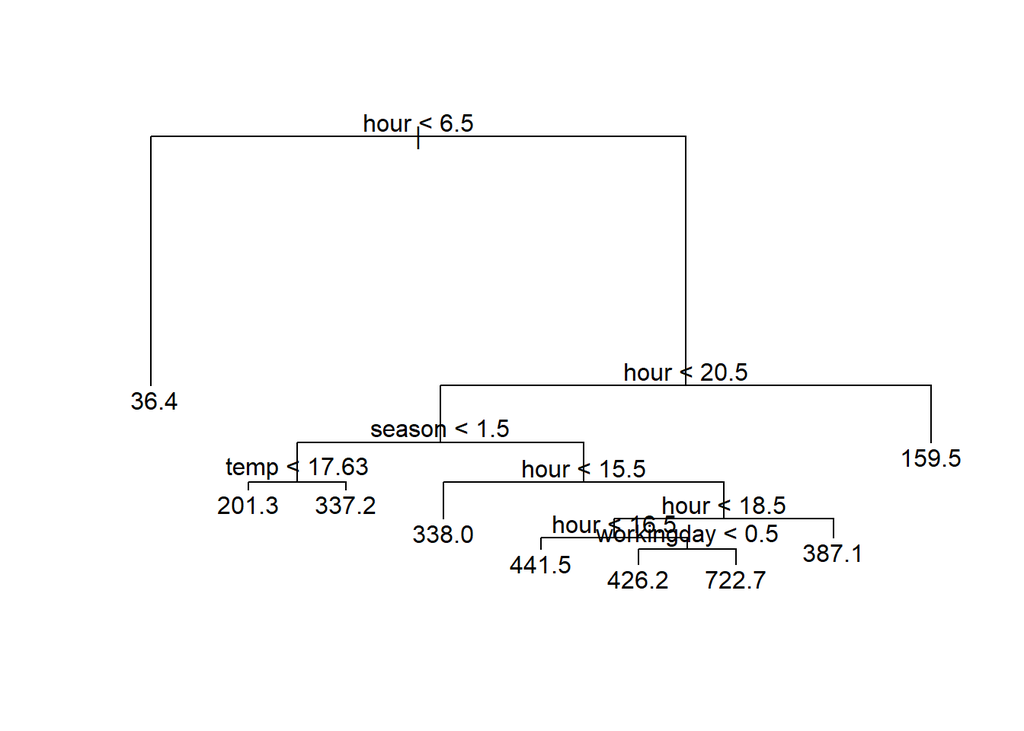

```r
plot(count.tree)
text(count.tree)
```

Metodą zbioru walidacyjnego szacujemy błąd testowy.

```r
count.tree.pred <- predict(count.tree, newdata = bike[test, ])
mean((count.tree.pred - bike$count[test])^2)
```

```
## [1] 14922.38
```

Wyznaczamy optymalne poddrzewo metodą przycinania sterowanego złożonością.

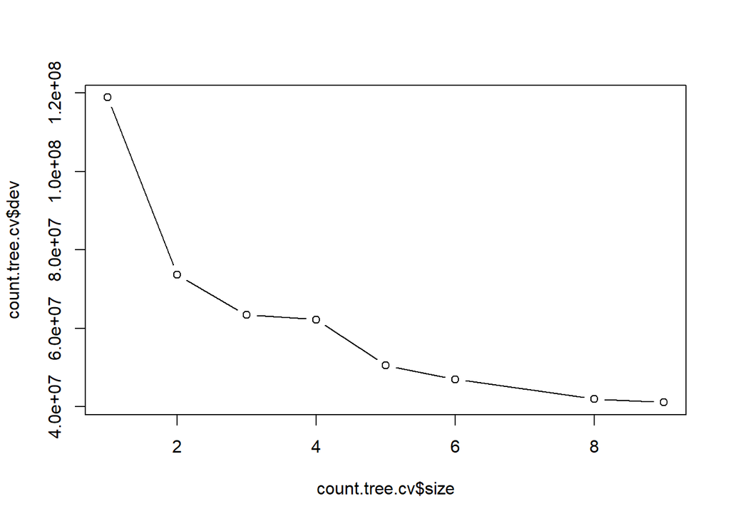

```r
count.tree.cv <- cv.tree(count.tree)
plot(count.tree.cv$size, count.tree.cv$dev, type = "b")
```

W tym przypadku przycinanie drzewa nie wytworzy bardziej optymalnego drzewa.

### Bagging

```r
count.bag <- randomForest(count ~ ., data = bike, subset = train, mtry = 6, importance = TRUE)
count.bag
```

```
##
## Call:
##  randomForest(formula = count ~ ., data = bike, mtry = 6, importance = TRUE,      subset = train)
##                Type of random forest: regression
##                      Number of trees: 500
## No. of variables tried at each split: 6
##
##           Mean of squared residuals: 3419.752
##                     % Var explained: 92.13
```

Wyznaczenie ważności predyktorów.

```r
importance(count.bag)
```

```
##               %IncMSE IncNodePurity
## season      21.761500       2621327
## holiday      7.881410        319032
## workingday 108.902337       9462096
## weather     29.419249       1907762
## temp        31.684765       6760491
## atemp       33.370078       8070366
## humidity    34.875822       7042892
## windspeed    9.375059       2218487
## month       30.952319       4332011
## day         14.935514       2350256
## hour       241.329757      72000460
```

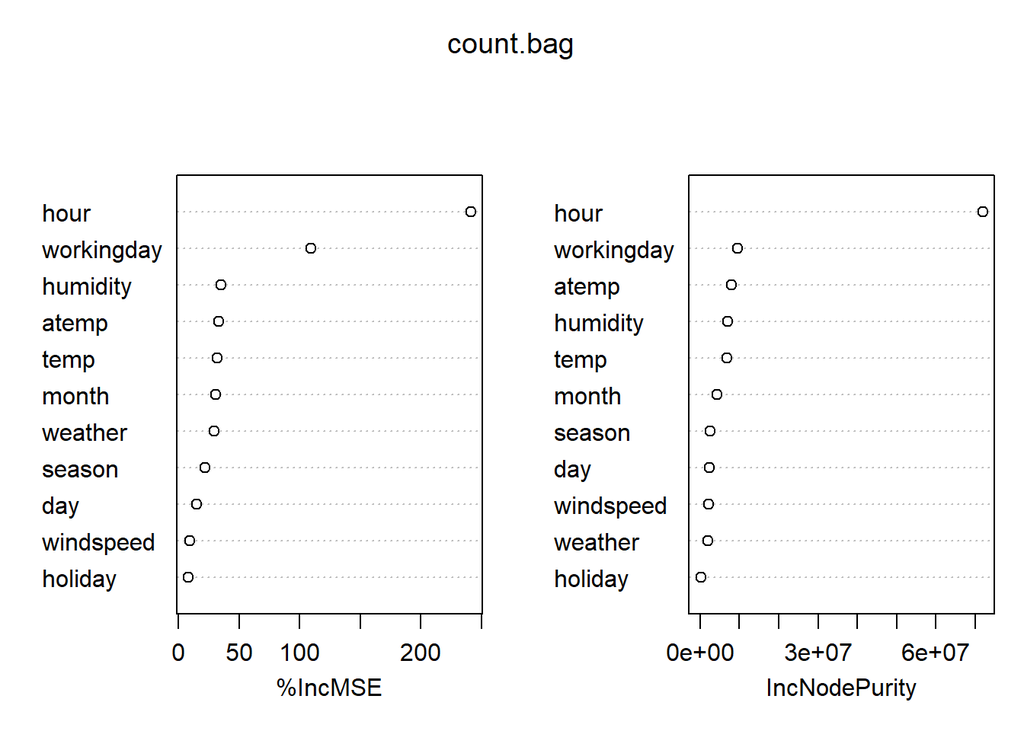

```r
varImpPlot(count.bag)
```

Oszacowanie błędu testowego dla poprzednio wyznaczonego zbioru walidacyjnego.

```r
count.bag.pred <- predict(count.bag, newdata = bike[test,])
mean((count.bag.pred - bike$count[test])^2)
```

```
## [1] 3535.589
```

### Lasy losowe

Lasy losowe dla regresji `count` względem wszystkich pozostałych zmiennych.

```r
count.rf <- randomForest(count ~ ., data = bike, subset = train, importance = TRUE)
count.rf
```

```
##
## Call:
##  randomForest(formula = count ~ ., data = bike, importance = TRUE,      subset = train)
##                Type of random forest: regression
##                      Number of trees: 500
## No. of variables tried at each split: 3
##
##           Mean of squared residuals: 7550.433
##                     % Var explained: 82.63
```

Wyznaczenie ważności predyktorów.

```r
importance(count.rf)
```

```
##               %IncMSE IncNodePurity
## season      25.008476     3257374.9
## holiday      7.425877      269313.6
## workingday  55.363252     4611507.5
## weather     27.469724     2345146.6
## temp        32.851783     8850774.1
## atemp       33.619568    10204658.1
## humidity    38.591605    11114850.1
## windspeed   16.229080     4658768.7
## month       33.692035     5609031.7
## day         19.540745     4530473.6
## hour       122.840444    57775470.3
```

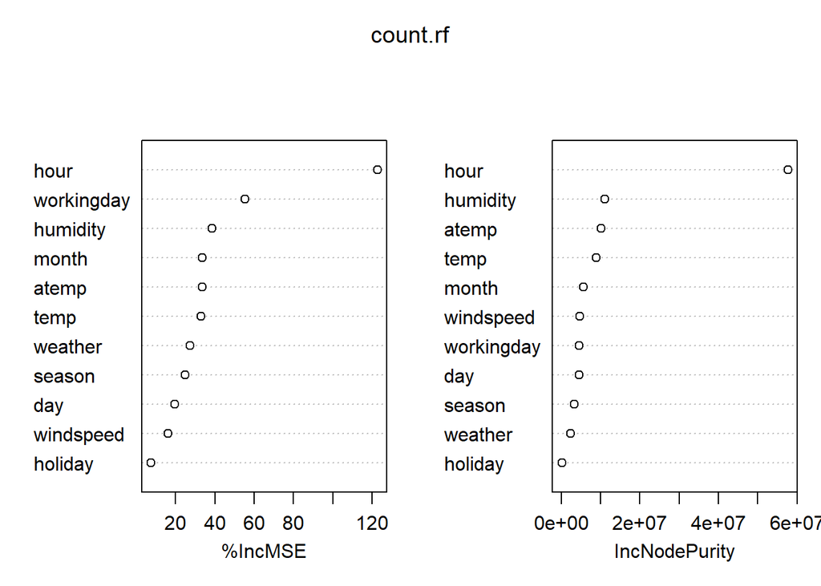

```r
varImpPlot(count.rf)
```

Oszacowanie błędu testowego dla poprzednio wyznaczonego zbioru walidacyjnego.

```r
count.rf.pred <- predict(count.rf, newdata = bike[test,])
mean((count.rf.pred - bike$count[test])^2)
```

```
## [1] 7368.481
```

### Boosting

Boosting dla regresji `count` względem pozostałych zmiennych.

```r
count.boost <- gbm(count ~ ., data = bike[train, ], distribution = "gaussian", n.trees = 5000, interaction.depth = 4)
count.boost
```

```
## gbm(formula = count ~ ., distribution = "gaussian", data = bike[train,
##     ], n.trees = 5000, interaction.depth = 4)
## A gradient boosted model with gaussian loss function.
## 5000 iterations were performed.
## There were 11 predictors of which 11 had non-zero influence.
```

Wyznaczenie ważności predyktorów.

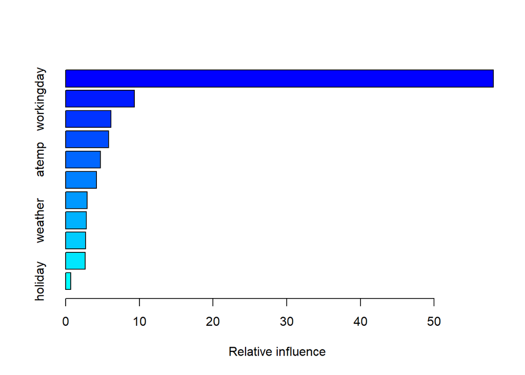

```
##                   var    rel.inf
## hour             hour 58.0219696
## workingday workingday  9.3112273
## humidity     humidity  6.1295144
## temp             temp  5.8417528
## atemp           atemp  4.7099572
## month           month  4.2118339
## day               day  2.9191887
## weather       weather  2.8318967
## windspeed   windspeed  2.6991856
## season         season  2.6322500
## holiday       holiday  0.6912238
```

```r
summary(count.boost)
```

Oszacowanie błędu testowego dla poprzednio wyznaczonego zbioru walidacyjnego.

```r
count.boost.pred <- predict(count.boost, newdata = bike[test,], n.trees = 5000)
mean((count.boost.pred - bike$count[test])^2)
```

```
## [1] 2892.787
```

To samo dla `shrinkage = 0.01`.

```r
count.boost <- gbm(count ~ ., data = bike[train, ], distribution = "gaussian", n.trees = 5000, interaction.depth = 4, shrinkage = 0.01)
count.boost.pred <- predict(count.boost, newdata = bike[test,], n.trees = 5000)
mean((count.boost.pred - bike$count[test])^2)
```

```
## [1] 3110.833
```

To samo dla `interaction.depth = 1`.

```r
count.boost <- gbm(count ~ ., data = bike[train, ], distribution = "gaussian", n.trees = 5000, interaction.depth = 1, shrinkage = 0.01)
count.boost.pred <- predict(count.boost, newdata = bike[test,], n.trees = 5000)
mean((count.boost.pred - bike$count[test])^2)
```

```
## [1] 12862.14
```